# identifying_viral_metrics_environmental

Bridget Hegarty, James Riddell

7/23/2022

This Rmarkdown file takes outputs from viral identification tools and merges them into one file, "{dataset}_merged_viral_id_outputs.csv", which is the input for identifying_viral_metrics_environmental.Rmd.

Please reach out to James Riddell (riddell.26@buckeyemail.osu.edu) or Bridget Hegarty (beh53@case.edu) regarding any issues, or open an issue on github.

TO DO: - add kaiju and DVF

```r
library(ggplot2)
library(plyr)
library(reshape2)
library(viridis)
library(tidyr)
library(dplyr)
library(readr)
library(data.table)
```

1. For this script’s inputs, the user must merge each viral identification tool output with the following specified filenames into one tab-separated file. Replace the filenames with their paths if needed into the variables in the ‘inputs’ chunk.

   General filenames for each tool: Checkv: quality_summary.tsv VIBRANT: VIBRANT_genome_quality_${assembly}.tsv Virsorter: VIRSorter_global-phage-signal.csv Virsorter2: final-viral-score.tsv DeepVirFinder: ${assembly}.fasta_gt2500bp_dvfpred.txt Kaiju: ${assembly}.kaiju.names.out
2. Make sure all fasta headers (assembly, contig) are consistent within and across tools. Chunks for each tool do contain some lines for cleaning up these features, but due to their variability it will be the user’s responsibility to make sure they match across tools.
3. Check each chunk and ensure all columns are accounted for. For example, if you don’t have “assembly” and called it something else, please either remove it from this script or modify your input files.
4. This script is designed for contigs > 3000 basepairs. It can be modified to be higher or lower, but going lower will greatly increase the size of the dataframe and memory usage.

```r
# dataset name for file organization and outputs for metrics file
dataset_name <- "drinking_water"
# checkV
checkV_path <- "DrinkingWaterToolOutput/merged_checkV_allcontigs.tsv"
# VIBRANT
vibrant_path <- "DrinkingWaterToolOutput/vibrant_merged_contig_list_all.txt"
# DeepVirFinder
dvf_path <- "DrinkingWaterToolOutput/merged_lake_michigan_dvf_assemblies.tsv"
# Virsorter
vs_path <- "DrinkingWaterToolOutput/vs_merged_all.txt"
# Virsorter2
vs2_path <- "DrinkingWaterToolOutput/vs2_merged_file.txt"
# Kaiju
kj_path <- "DrinkingWaterToolOutput/merged_lake_michigan_kaiju_assemblies.tsv"
# KB cutoff
KB_CUTOFF <- 3000
```

# All Viral Contigs

## checkV

```r
checkV <- fread(checkV_path,
                sep="\t",
                header = T,
                select = c(
                    'contig_id',
                    'assembly',
                    'provirus',
                    'completeness',
                    'contamination',
                    'viral_genes',
                    'host_genes',
                    'gene_count',
                    'contig_length',
                    'checkv_quality'
                    )
                ) %>%
    rename(
        contig = contig_id,
        checkv_provirus = provirus,
        checkv_completeness = completeness,
        checkv_contamination = contamination,
        checkv_viral_genes = viral_genes,
        checkv_host_genes = host_genes,
        checkv_total_genes = gene_count,
        checkv_length = contig_length
        )
checkV$method = 'checkv'
checkV$contig <- sub("\\.", "_", checkV$contig)
checkV$uniq_contig <- paste(checkV$assembly, checkV$contig, sep = "--")
```

## VIBRANT

```r
vb_c <- fread(vibrant_path,
              header = T,
              sep = "\t",
              select = c(
                  'scaffold',
                  'assembly',
                  'type',
                  'quality'
                  )
              ) %>%
    rename(
        contig = scaffold,
        vibrant_quality = quality
        )
vb_c$method <- "vibrant"
vb_c$vibrant_prophage <- "No"
vb_c$vibrant_prophage[grep("_fragment_", vb_c$contig)] <- "Yes"
vb_c$contig <- gsub("_fragment_.*", "", vb_c$contig)
vb_c$contig <- sub("\\.", "_", vb_c$contig)
vb_c$uniq_contig <- paste(vb_c$assembly, vb_c$contig, sep = "--")
vb_c <- vb_c[!duplicated(vb_c$uniq_contig),]
```

## DeepVirFinder - to run

```r
dvf_c <- fread(dvf_path,
               header = T,
               sep = "\t",
               select = c(
                   'name',
                   'assembly',
                   'score',
                   'pvalue'
                   )
               ) %>%
    rename(
        contig = name
        )
dvf_c$contig <- sub("\\.", "_", dvf_c$contig)

dvf_c$bh_pvalue <- p.adjust(dvf_c$pvalue, method = "BH")
```

## VirSorter

```r
vs_c <- fread(vs_path,
              select = c(
                  'assembly',
                  'contig_id',
                  'category'
                  ),
              ) %>%
  rename(contig = contig_id) %>%
  drop_na(contig)
vs_c$contig <- sub("VIRSorter_", "", vs_c$contig)
vs_c$contig <- sub("-circula", "", vs_c$contig)
vs_c$contig <- sub("uth", "South", vs_c$contig)
vs_c$contig <- sub("pannenburg", "Spannenburg", vs_c$contig)
vs_c$contig <- sub("\\.", "_", vs_c$contig)
vs_c$uniq_contig <- paste(vs_c$assembly, vs_c$contig, sep = "--")

vs_c <- vs_c[!duplicated(vs_c$uniq_contig),]
vs_c <- vs_c %>% drop_na(uniq_contig)
```

## VirSorter2

```r
vs2_c <- fread(vs2_path,
                    header = T,
                    sep = '\t',
                    select = c(
                        'seqname',
                        'assembly',
                        'dsDNAphage',
                        'ssDNA',
                        'max_score',
                        'max_score_group',
                        'hallmark',
                        'viral',
                        'cellular'
                    )
               ) %>%
              separate(
                  col = seqname,
                  into = c("contig", "type"),
                  sep = "\\|\\|",
                  remove = T
                  )
vs2_c$assembly <- sub("_3000", "", vs2_c$assembly)
vs2_c$contig <- sub("\\.", "_", vs2_c$contig)
vs2_c$uniq_contig <- paste(vs2_c$assembly, vs2_c$contig, sep="--")
vs2_c <- vs2_c[!duplicated(vs2_c$uniq_contig),]
```

## Kaiju - to run

(parsing when reading the file in “fails” for sequences that weren’t classified)

```r
kj_c <- fread(kj_path)

colnames(kj_c) <-c(
    "Classified",
    "Contig",
    "NCBI_taxon",
    "len",
    "ID_best",
    "IDs_all",
    "Seq",
    "Name"
    )
kj_c$Contig <- gsub('_', '', kj_c$Contig)
kj_c$Contig <- sub("\\.", "_", kj_c$Contig)

kj_c <- setDT(kj_c)[, c("assembly", "contig") := tstrsplit(Contig, "--")]
kj_c <- setDT(kj_c)[, c("Kaiju_Viral", "Kingdom") := tstrsplit(Name, ";", keep = c(1, 2))]
```

```r
# Quick glimpse of cellular vs viral sequence classification by Kaiju by assembly
table(kj_c$assembly, kj_c$Kaiju_Viral)
```

## Merging

to do: this step isn’t working properly

```r
viruses <- full_join(x=vs2_c, y=checkV, by = c("uniq_contig", "assembly"))
```

```
Error: Join columns must be present in data.
x Problem with `uniq_contig`.
Run `rlang::last_error()` to see where the error occurred.
```

calculate percent viral/host/unknown

```r
viruses$percent_host <- viruses$checkv_host_genes/viruses$checkv_total_genes*100
viruses$percent_viral <- viruses$checkv_viral_genes/viruses$checkv_total_genes*100
viruses$percent_unknown <- 100-(viruses$checkv_host_genes+viruses$checkv_viral_genes)/viruses$checkv_total_genes*100
```

get rid of NAs for downstream processing

```r
# checkV
viruses$percent_viral[is.na(viruses$percent_viral)] <- 0
viruses$percent_unknown[is.na(viruses$percent_unknown)] <- 0

# VIBRANT
viruses$vibrant_quality[is.na(viruses$vibrant_quality)] <- 0

# DeepVirFinder
viruses$score[is.na(viruses$score)] <- 0
viruses$bh_pvalue[is.na(viruses$bh_pvalue)] <- 0

# VirSorter2
viruses$viral[is.na(viruses$viral)] <- 0
viruses$hallmark[is.na(viruses$hallmark)] <- 0

#Virsorter
viruses$Category[is.na(viruses$Category)] <- 0

# Kaiju
viruses$Kaiju_Viral[is.na(viruses$Kaiju_Viral)] <- "unknown"
viruses$Kingdom[is.na(viruses$Kingdom)] <- "unknown"
```

```r
viruses_filename <- 'merged_viral_id_outputs.csv'
write.csv(viruses, paste(dataset_name, viruses_filename, sep='_'))
```

Data cleaning is done! Export viruses to tsv and load into identifying_viral_metrics.Rmd for metrics on tool outputs. The code for metrics is also pasted below, but it is not recommended running it in the same R session due to memory issues. The construction of the final dataframe essentially doubles the memory being used, and even with garbage collector can make Rstudio unresponsive.

TODO: ADD ENVIRONMENTAL METRICS LIKE SHANNON, ALPHA DIVERSITY.

This section defines a viralness score “keep_score” based on the tool classifications. A final keep_score above 1 indicates we will keep that sequence and call it viral.

VIBRANT Quality == “High Quality Draft”: +1 Quality == “Medium Quality Draft”: +1 Quality == “Low Quality Draft” & provirus == TRUE: +0.5

DeepVirFinder: Score >= 0.7: +0.5

Kaiju: Kaiju_viral = “cellular organisms”: -1 Kaiju_viral = “Viruses”: +1

CheckV viral_genes == 0 and host_genes >= 1: keep_score = 0 If 3*viral_genes <= host_genes: keep_score = 0 If length > 50,000 and hallmark == 0: keep_score = 0 If %unknown >= 75: +0.5

Users can decide which combination is appropriate for them and only need to run the chunks for the appropriate tools.

```r
getting_viral_set_1 <- function(input_seqs,
                                include_vibrant=FALSE,
                                include_virsorter2=FALSE,
                                include_deepvirfinder=FALSE,
                                include_checkV=FALSE,
                                include_kaiju=FALSE,
                                include_virsorter=FALSE) {

  keep_score <- rep(0, nrow(input_seqs))

  if (include_vibrant) {
    keep_score[input_seqs$vibrant_quality=="high quality draft"] <- keep_score[input_seqs$vibrant_quality=="high quality draft"] + 1
    keep_score[input_seqs$vibrant_quality=="medium quality draft"] <- keep_score[input_seqs$vibrant_quality=="medium quality draft"] + 1
    keep_score[input_seqs$vibrant_quality=="low quality draft" & input_seqs$provirus=="Yes"] <- keep_score[input_seqs$vibrant_quality=="low quality draft" & input_seqs$provirus=="Yes"] + 0.5
  }

  if (include_virsorter2) {
    keep_score[input_seqs$viral>=50] <- keep_score[input_seqs$viral>=50] + 0.5
    keep_score[input_seqs$hallmark>2] <- keep_score[input_seqs$hallmark>2] + 1
    keep_score[input_seqs$viral>=95] <- keep_score[input_seqs$viral>=95] + 1
  }

  if (include_virsorter) {
    keep_score[input_seqs$category==1] <- keep_score[input_seqs$category==1] + 1
    keep_score[input_seqs$category==2] <- keep_score[input_seqs$category==2] + 1
    keep_score[input_seqs$category==3] <- keep_score[input_seqs$category==3] + 0.5
    keep_score[input_seqs$category==4] <- keep_score[input_seqs$category==4] + 1
    keep_score[input_seqs$category==5] <- keep_score[input_seqs$category==5] + 1
    keep_score[input_seqs$category==6] <- keep_score[input_seqs$category==6] + 0.5
  }

  if (include_deepvirfinder) {
    keep_score[input_seqs$score>=0.7] <- keep_score[input_seqs$score>=0.7] + 0.5
#   keep_score[input_seqs$score>=0.9] <- keep_score[input_seqs$score>=0.9] + 0.5
  }

  if (include_kaiju) {
    keep_score[input_seqs$Kaiju_Viral=="cellular organisms"] <- keep_score[input_seqs$Kaiju_Viral=="cellular organisms"] - 1
    keep_score[input_seqs$Kaiju_Viral=="Viruses"] <- keep_score[input_seqs$Kaiju_Viral=="Viruses"] + 1
  }

  if (include_checkV) {
    keep_score[input_seqs$viral_genes==0 & input_seqs$host_genes>=1] <- 0
    keep_score[(input_seqs$viral_genes*3) <= input_seqs$host_genes] <- 0
    keep_score[input_seqs$contig_length>50000 & input_seqs$hallmark==0] <- 0
    keep_score[input_seqs$percent_unknown>=75] <- keep_score[input_seqs$percent_unknown>=75] + 0.5
  }

  return(keep_score)

}
```

## just vibrant

```r
viruses$keep_score_vb <- getting_viral_set_1(viruses, include_vibrant = T,
                                            include_virsorter2 = F,
                                            include_checkV = F,
                                            include_kaiju = F,
                                            include_deepvirfinder = F)
```

## vibrant + checkV

```r
viruses$keep_score_vb_cv <- getting_viral_set_1(viruses, include_vibrant = T,
                                            include_virsorter2 = F,
                                            include_checkV = T,
                                            include_kaiju = F,
                                            include_deepvirfinder = F)
```

## vibrant + checkV + kaiju

```r
viruses$keep_score_vb_cv_kj <- getting_viral_set_1(viruses, include_vibrant = T,
                                            include_virsorter2 = F,
                                            include_checkV = T,
                                            include_kaiju = T,
                                            include_deepvirfinder = F)
```

## vibrant + checkV + kaiju + deepvirfinder

```r
viruses$keep_score_vb_cv_kj_dvf <- getting_viral_set_1(viruses, include_vibrant = T,
                                            include_virsorter2 = F,
                                            include_checkV = T,
                                            include_kaiju = T,
                                            include_deepvirfinder = T)
```

## vibrant + virsorter2 + checkV + kaiju

```r
viruses$keep_score_vb_vs2_cv_kj <- getting_viral_set_1(viruses, include_vibrant = T,
                                            include_virsorter2 = T,
                                            include_checkV = T,
                                            include_kaiju = T,
                                            include_deepvirfinder = F)
```

#all: vibrant + virsorter2 + checkV + kaiju + deepvirfinder

```r
viruses$keep_score_all <- getting_viral_set_1(viruses, include_vibrant = T,
                                            include_virsorter2 = T,
                                            include_checkV = T,
                                            include_kaiju = T,
                                            include_deepvirfinder = T,
                                            include_virsorter = T)
```

## just virsorter2

```r
viruses$keep_score_vs2 <- getting_viral_set_1(viruses, include_vibrant = F,
                                            include_virsorter2 = T,
                                            include_checkV = F,
                                            include_kaiju = F,
                                            include_deepvirfinder = F)
```

## virsorter2 + checkV

```r
viruses$keep_score_vs2_cv <- getting_viral_set_1(viruses, include_vibrant = F,
                                            include_virsorter2 = T,
                                            include_checkV = T,
                                            include_kaiju = F,
                                            include_deepvirfinder = F)
```

## virsorter2 + checkV + kaiju

```r
viruses$keep_score_vs2_cv_kj <- getting_viral_set_1(viruses, include_vibrant = F,
                                            include_virsorter2 = T,
                                            include_checkV = T,
                                            include_kaiju = T,
                                            include_deepvirfinder = F)
```

## virsorter2 + checkV + kaiju + deepvirfinder

```r
viruses$keep_score_vs2_cv_kj_dvf <- getting_viral_set_1(viruses, include_vibrant = F,
                                            include_virsorter2 = T,
                                            include_checkV = T,
                                            include_kaiju = T,
                                            include_deepvirfinder = T)
```

## just checkV

```r
viruses$keep_score_cv <- getting_viral_set_1(viruses, include_vibrant = F,
                                            include_virsorter2 = F,
                                            include_checkV = T,
                                            include_kaiju = F,
                                            include_deepvirfinder = F)
```

## checkV + kaiju

```r
viruses$keep_score_cv_kj <- getting_viral_set_1(viruses, include_vibrant = F,
                                            include_virsorter2 = F,
                                            include_checkV = T,
                                            include_kaiju = T,
                                            include_deepvirfinder = F)
```

## just kaiju

```r
viruses$keep_score_kj <- getting_viral_set_1(viruses, include_vibrant = F,
                                            include_virsorter2 = F,
                                            include_checkV = F,
                                            include_kaiju = T,
                                            include_deepvirfinder = F,
                                            include_virsorter = F)
```

## just deepvirfinder

```r
viruses$keep_score_dvf <- getting_viral_set_1(viruses, include_vibrant = F,
                                            include_virsorter2 = F,
                                            include_checkV = F,
                                            include_kaiju = F,
                                            include_deepvirfinder = T)
```

## deepvirfinder + checkV

```r
viruses$keep_score_dvf_cv <- getting_viral_set_1(viruses, include_vibrant = F,
                                            include_virsorter2 = F,
                                            include_checkV = T,
                                            include_kaiju = F,
                                            include_deepvirfinder = T)
```

## deepvirfinder + checkV + kaiju

```r
viruses$keep_score_dvf_cv_kj <- getting_viral_set_1(viruses, include_vibrant = F,
                                            include_virsorter2 = F,
                                            include_checkV = T,
                                            include_kaiju = T,
                                            include_deepvirfinder = T,
                                            include_virsorter = F)
```

```r
viruses$keep_score_vs2_cv_kj <- getting_viral_set_1(viruses, include_vibrant = F,
                                            include_virsorter2 = F,
                                            include_checkV = T,
                                            include_kaiju = T,
                                            include_deepvirfinder = T)
```

## just virsorter

```r
viruses$keep_score_vs <- getting_viral_set_1(viruses, include_vibrant = F,
                                            include_virsorter2 = F,
                                            include_checkV = F,
                                            include_kaiju = F,
                                            include_deepvirfinder = F,
                                            include_virsorter = T)
```

## virsorter + checkV

```r
viruses$keep_score_vs_cv <- getting_viral_set_1(viruses, include_vibrant = F,
                                            include_virsorter2 = F,
                                            include_checkV = T,
                                            include_kaiju = F,
                                            include_deepvirfinder = F,
                                            include_virsorter = T)
```

## virsorter + checkV + kaiju

```r
viruses$keep_score_vs_cv_kj <- getting_viral_set_1(viruses, include_vibrant = F,
                                            include_virsorter2 = F,
                                            include_checkV = T,
                                            include_kaiju = T,
                                            include_deepvirfinder = F,
                                            include_virsorter = T)
```

## virsorter + checkV + kaiju + vibrant + deepvirfinder + virsorter2

```r
viruses$keep_score_vs_cv_kj <- getting_viral_set_1(viruses, include_vibrant = T,
                                            include_virsorter2 = T,
                                            include_checkV = T,
                                            include_kaiju = T,
                                            include_deepvirfinder = T,
                                            include_virsorter = T)
```

## virsorter + checkV + kaiju + vibrant

```r
viruses$keep_score_vs_cv_kj_vb <- getting_viral_set_1(viruses, include_vibrant = T,
                                            include_virsorter2 = F,
                                            include_checkV = T,
                                            include_kaiju = T,
                                            include_deepvirfinder = F,
                                            include_virsorter = T)
```

## virsorter + checkV + kaiju + virsorter2 + vibrant

```r
viruses$keep_score_vs_cv_kj_vb_vs2 <- getting_viral_set_1(viruses, include_vibrant = T,
                                            include_virsorter2 = T,
                                            include_checkV = T,
                                            include_kaiju = T,
                                            include_deepvirfinder = F,
                                            include_virsorter = T)
```

```r
viruses$keep_score_vs_cv_kj_vs2_dvf <- getting_viral_set_1(viruses, include_vibrant = F,
                                            include_virsorter2 = T,
                                            include_checkV = T,
                                            include_kaiju = T,
                                            include_deepvirfinder = T,
                                            include_virsorter = T)
```

TODO WHAT DO I DO ABOUT THE ZEROS???? # Plot of how many methods identify a contig

```r
viruses_high <- viruses[viruses$keep_score_all>=1,]
viruses_high_mod <- viruses_high %>% select(keep_score_vb_cv, keep_score_dvf_cv,keep_score_vs2_cv, keep_score_vs_cv, keep_score_cv_kj)
viruses_high_mod <- apply(viruses_high_mod, c(1,2), function(x) {if (x >= 1) {x <- 1} else {x <- 0}})
viruses_high_mod <- as_tibble(viruses_high_mod)

virusHighCount <- function(df, tool_combo) {
    tb <- rowSums(df[df[,tool_combo]>0,])
    if (length(tb) == 0) {
        return (0)
    }
    else {
        return (table(tb))
    }
}

sm <- as.data.frame(rbind(table(rowSums(viruses_high_mod[viruses_high_mod$keep_score_vb_cv>0,])),
                          table(rowSums(viruses_high_mod[viruses_high_mod$keep_score_dvf_cv>0,])),
                          table(rowSums(viruses_high_mod[viruses_high_mod$keep_score_cv_kj>0,]))
                          )
)

sm <- as.data.frame(
    rbind(
        virusHighCount(viruses_high_mod, "keep_score_vb_cv"),
        virusHighCount(viruses_high_mod, "keep_score_dvf_cv"),
        virusHighCount(viruses_high_mod, "keep_score_vs2_cv"),
        virusHighCount(viruses_high_mod, "keep_score_vs_cv"),
        virusHighCount(viruses_high_mod, "keep_score_cv_kj")
    )
)

sm$method <- c("vibrant", "deepvirfinder", "virsorter2", "virsorter", "kaiju")
sm
```

| 1 | 2 | 3 | method |
| --- | --- | --- | --- |
| 386 | 1190 | 2484 | vibrant |
| 0 | 0 | 0 | deepvirfinder |
| 34778 | 10696 | 2484 | virsorter2 |
| 10654 | 10718 | 2484 | virsorter |
| 0 | 0 | 0 | kaiju |

Create list of contigs considered viral

```r
c_list <- data.frame(viruses_high$checkv_uniq_contig)
write_tsv(c_list, paste(dataset_name, "viruses_high_uniq_contig_list.tsv", sep='_'))
```

Export keep_score_high and list of contigs considered viral by the combined tool.

```r
write_tsv(viruses_high, paste(dataset_name, "viruses_high.tsv", sep='_'))
```

```r
sm_m <- reshape2::melt(sm)
colnames(sm_m) <- c("primary_method", "number_methods", "number")
```

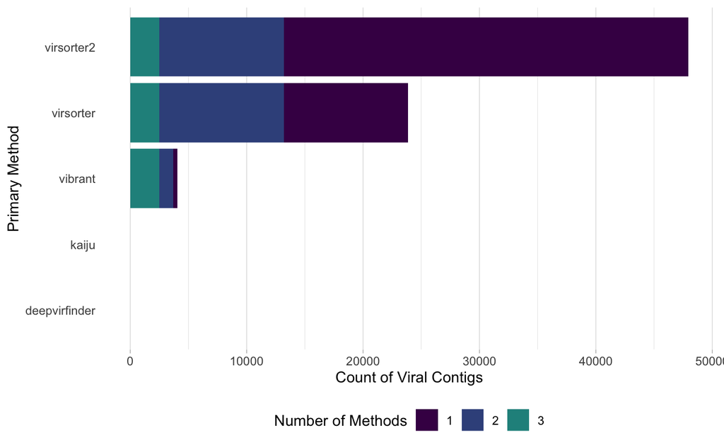

```r
ggplot(sm_m, aes(x=primary_method, y=number,
                   fill=number_methods)) +
  geom_bar(stat="identity") +
  theme_light() +
  coord_flip() +
  theme(
    panel.grid.major.y = element_blank(),
    panel.border = element_blank(),
    axis.ticks.y = element_blank(),
    legend.position = "bottom"
  ) +
  scale_fill_manual(name = 'Number of Methods',
                     values = alpha(c(viridis(5)), 1)) +
  xlab("Primary Method") +
  ylab("Count of Viral Contigs")
```

# Visualizing which tools led to a contig being selected

(alluvial plot) with help from: https://www.bioinfo-scrounger.com/archives/alluvial-and-Sankey/

```r
alluvial_data$keep_score <- "0-0.5"
alluvial_data$keep_score[alluvial_data$cum_sum>=1] <- "1-1.5"
alluvial_data$keep_score[alluvial_data$cum_sum>=2] <- "2-2.5"
alluvial_data$keep_score[alluvial_data$cum_sum>=3] <- "3-3.5"
alluvial_data$keep_score[alluvial_data$cum_sum>=4] <- "4-4.5"
alluvial_data$keep_score[alluvial_data$cum_sum>=5] <- "5+"

alluvial_data$keep_score <- factor(
    alluvial_data$keep_score,
    levels=c(
        "0-0.5",
        "1-1.5",
        "2-2.5",
        "3-3.5",
        "4-4.5",
        "5+"
        )
    )
```

[output not shown]

[figure not shown]

Get proportion of contigs from “viruses” classified as virus by combined tool:

```r
prop_viral <- paste(nrow(viruses_high) / nrow(viruses) * 100, "%", sep="")
prop_viral
```

```
[1] "8.14061206702808%"
```

Distribution of keep_score across “viruses” dataframe.

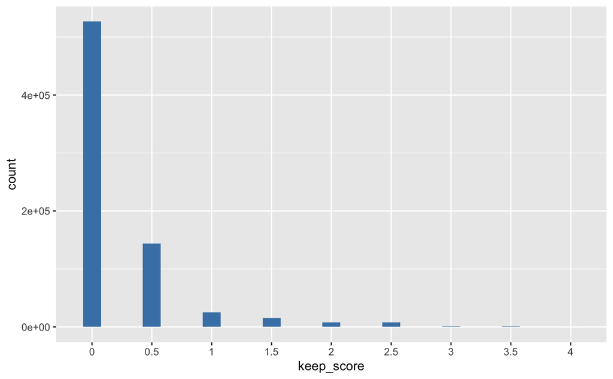

```r
keep_scores <- reshape2::melt(table(viruses$keep_score_all))

colnames(keep_scores) <- c('keep_score', 'count')
keep_scores[,'keep_score'] <- as.factor(keep_scores[,'keep_score'])

ggplot(data = keep_scores, aes(x = keep_score, y = count)) +
    geom_bar(stat="identity", width = 0.3, fill = 'steelblue')
```

Determine number of viral sequences with kaiju taxonomic classification

```r
tax_counts <- viruses_high %>% count(Kaiju_Viral, name = "num")
tax_counts$prop <- tax_counts$num / sum(tax_counts$num)
```